# NLP/Text Mining - Predicting product recommendation using model ensembling(Stacking)

Pulkit Kalia

19 August 2018

## Analysis Title of a product and predicting if the product will be recommended

### Synopsis

This dataset was taken from Kaggle and was used to predict if the product will be recommended. Variable Title was taken and corpus was created using TM library and most frequent words were analysed and used for predictions. Few new variables were also introduced after EDA which resulted in better ouput.

```r
set.seed(1)
setwd("C:\\R Programming\\Women's Clothing Reviews")
data<-read.csv("data.csv",stringsAsFactors = FALSE,na.strings = c(""," "))

library(tm)
library(SnowballC)
library(caTools)
library(dplyr)
library(textstem)
library(ngram)
Sys.setenv(JAVA_HOME='C:\\Program Files\\Java\\jre-10.0.2')
library(RWeka)
data$notNull<-as.factor(ifelse(is.na(data$Title)==TRUE,0,1))
data$Title[is.na(data$Title)]<-"Missing"


corpus = VCorpus(VectorSource(data$Title))
corpus = tm_map(corpus, content_transformer(tolower))
corpus = tm_map(corpus, removePunctuation)

exceptions   <- c("not","too","bad","just","no","but")
my_stopwords <- setdiff(stopwords("en"), exceptions)
corpus = tm_map(corpus, removeWords, my_stopwords)
corpus <- tm_map(corpus, lemmatize_strings)
corpus <- tm_map(corpus, PlainTextDocument)

corpus = tm_map(corpus, stemDocument)


#BigramTokenizer <- function(x) NGramTokenizer(x, Weka_control(min = 1, max = 3))
#frequencies <- TermDocumentMatrix(corpus, control = list(tokenize = BigramTokenizer))

#frequencies = DocumentTermMatrix(corpus)
frequencies = DocumentTermMatrix(corpus,control = list(weighting = function(x) weightTfIdf(x, normalize = TRUE)))
sparse = removeSparseTerms(frequencies, 0.98)

TitleSparse = as.data.frame(as.matrix(sparse))
colnames(TitleSparse) = make.names(colnames(TitleSparse))
TitleSparse$Rating = as.factor(data$Rating)
TitleSparse$Recommended.IND = as.factor(data$Recommended.IND)
```

## Including Plots for EDA

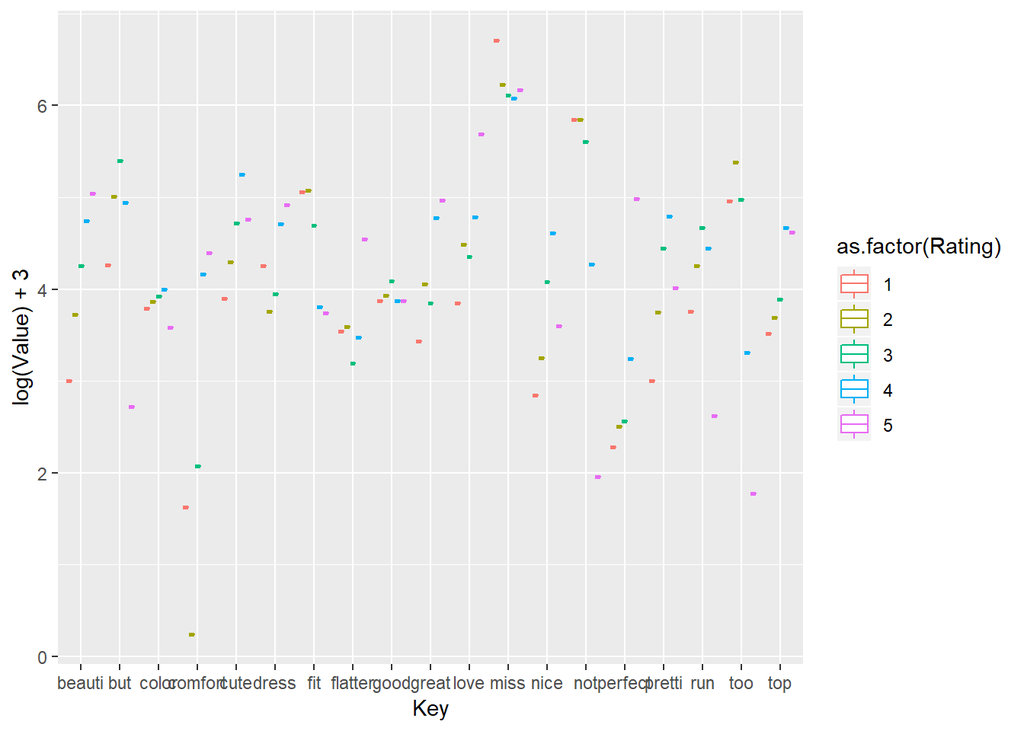

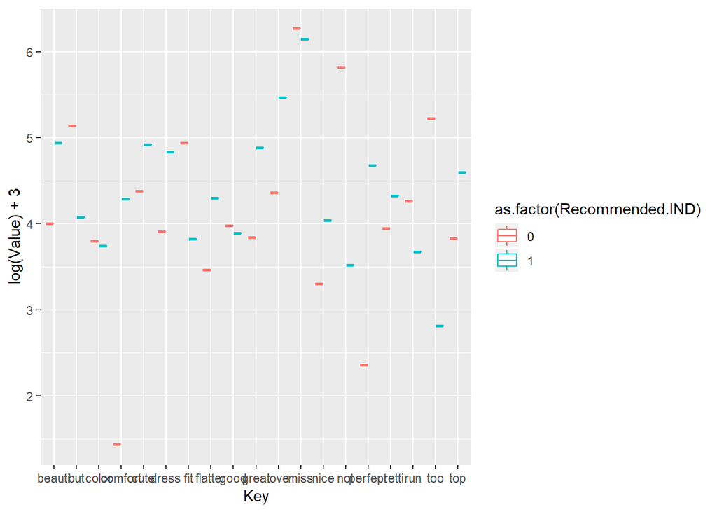

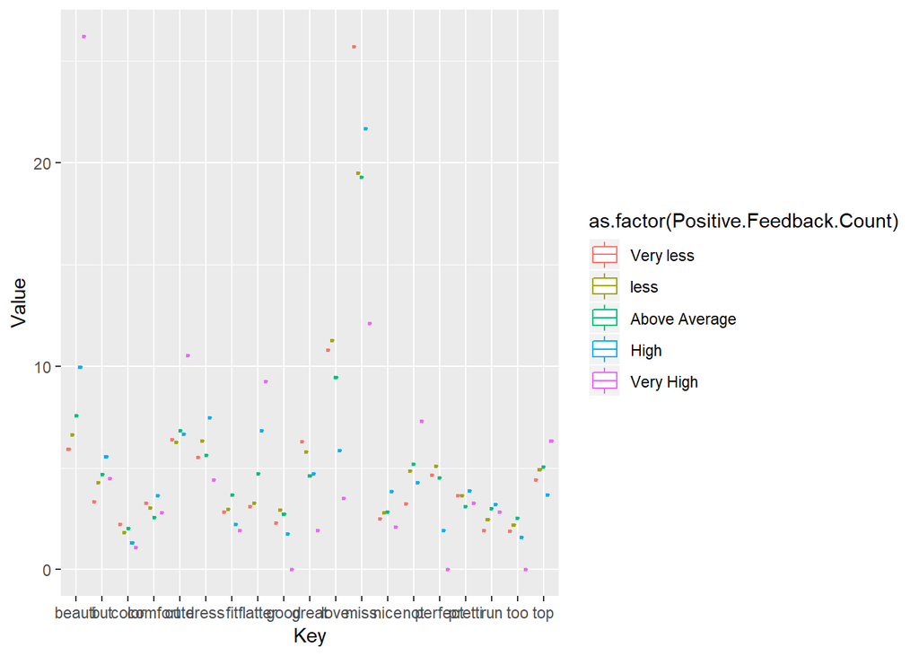

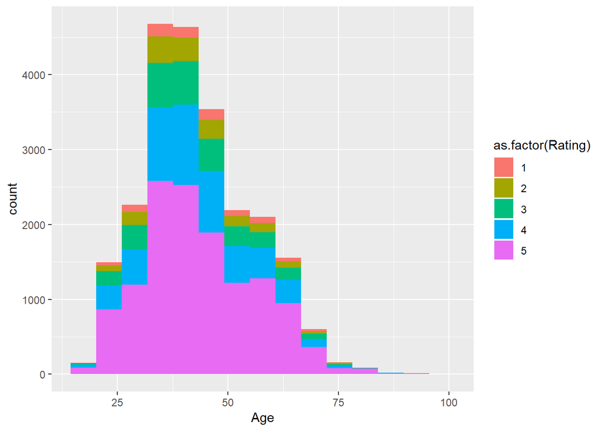

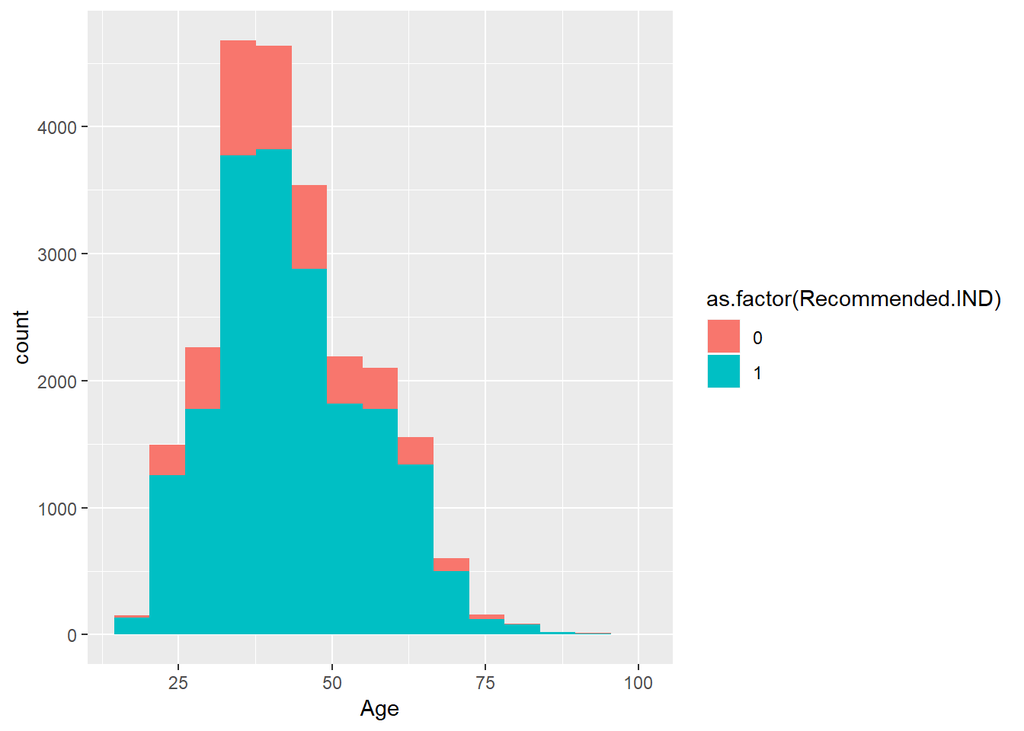

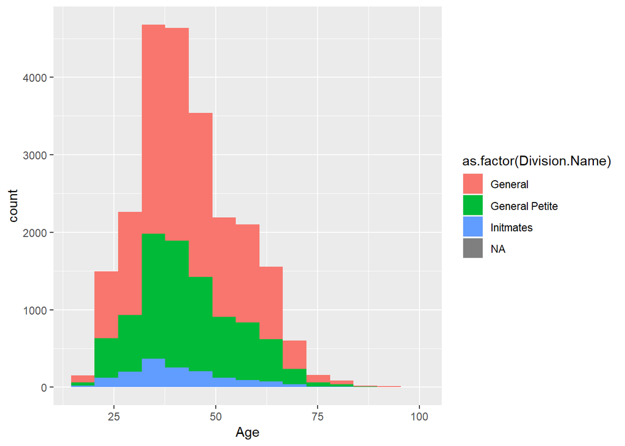

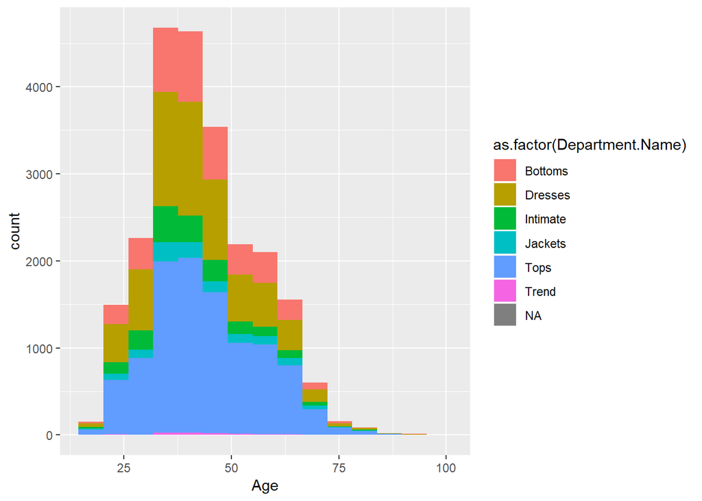

```
## # A tibble: 5 x 2
##   Rating `median(Age)`
##    <int>         <dbl>
## 1      1            42
## 2      2            41
## 3      3            40
## 4      4            41
## 5      5            41
```

```
## # A tibble: 2 x 2
##   Recommended.IND `median(Age)`
##             <int>         <dbl>
## 1               0            40
## 2               1            41
```

```
## # A tibble: 4 x 2
##   Division.Name  `median(Age)`
##   <chr>                  <dbl>
## 1 General                   41
## 2 General Petite            41
## 3 Initmates                 39
## 4 <NA>                      38
```

```
## # A tibble: 7 x 2
##   Department.Name `median(Age)`
##   <chr>                   <dbl>
## 1 Bottoms                    41
## 2 Dresses                    40
## 3 Intimate                   39
## 4 Jackets                    42
## 5 Tops                       42
## 6 Trend                      43
## 7 <NA>                       38
```

[output not shown]

Now using only values from corpus/Title variable and few Engineered variable to create models.

```r
TitleSparse$Positive.Feedback.Count<-NULL
TitleSparse$Recommended.IND<-as.factor(data$Recommended.IND)
TitleSparse$containsdots<-ifelse(grepl("\\...",data$Title),1,0)
TitleSparse$containsexclamation<-ifelse(grepl("\\!",data$Title),1,0)
TitleSparse$containsquestionmark<-ifelse(grepl("\\?",data$Title),1,0)

explore<-TitleSparse %>% group_by(containsdots) %>% summarise(mean(as.numeric(Recommended.IND)-1))
print(explore)
```

```
## # A tibble: 2 x 2
##   containsdots `mean(as.numeric(Recommended.IND) - 1)`
##          <dbl>                                   <dbl>
## 1            0                                   0.829
## 2            1                                   0.605
```

```r
explore<-TitleSparse %>% group_by(containsexclamation) %>% summarise(mean(as.numeric(Recommended.IND)-1))
print(explore)
```

```
## # A tibble: 2 x 2
##   containsexclamation `mean(as.numeric(Recommended.IND) - 1)`
##                 <dbl>                                   <dbl>
## 1                   0                                   0.800
## 2                   1                                   0.924
```

```r
explore<-TitleSparse %>% group_by(containsquestionmark) %>% summarise(mean(as.numeric(Recommended.IND)-1))
print(explore)
```

```
## # A tibble: 2 x 2
##   containsquestionmark `mean(as.numeric(Recommended.IND) - 1)`
##                  <dbl>                                   <dbl>
## 1                    0                                   0.823
## 2                    1                                   0.669
```

```r
library(caTools)
splits<-sample.split(TitleSparse,SplitRatio = 0.8)
train<-subset(TitleSparse,splits==TRUE)
test<-subset(TitleSparse,splits==FALSE)

library(party)
library(caret)
```

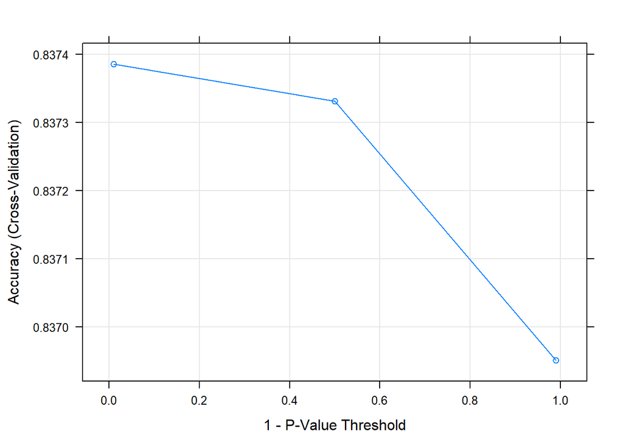

```r
output.tree <- train(factor(Recommended.IND)~.,data=train,method="ctree",trControl=trainControl(method="cv",number = 5))
predictionsctree<-predict(output.tree,test,type="prob")[,2]


predictionsctreetrain<-predict(output.tree,train,type="prob")[,2]
plot(output.tree)
```

```r
print(output.tree)
```

```
## Conditional Inference Tree
##
## 18381 samples
##    22 predictor
##     2 classes: '0', '1'
##
## No pre-processing
## Resampling: Cross-Validated (5 fold)
## Summary of sample sizes: 14704, 14704, 14705, 14706, 14705
## Resampling results across tuning parameters:
##
##   mincriterion  Accuracy   Kappa
##   0.01          0.8373859  0.2525123
##   0.50          0.8373315  0.2477633
##   0.99          0.8369510  0.2203518
##
## Accuracy was used to select the optimal model using the largest value.
## The final value used for the model was mincriterion = 0.01.
```

```r
modelglm<-train(factor(Recommended.IND)~.,data=train,method="glm",trControl=trainControl(method="cv",number = 5))
predictionsGLM<-data.frame(predict(modelglm,test,type="prob"))
predictionsGLM<-predictionsGLM[,2]


predictionsGLMtrain<-data.frame(predict(modelglm,train,type="prob"))
predictionsGLMtrain<-predictionsGLMtrain[,2]
print(table(predictionsGLM>0.5,test$Recommended.IND))
```

```
##
##            0    1
##   FALSE  145   96
##   TRUE   748 4116
```

```r
print(modelglm)
```

```
## Generalized Linear Model
##
## 18381 samples
##    22 predictor
##     2 classes: '0', '1'
##
## No pre-processing
## Resampling: Cross-Validated (5 fold)
## Summary of sample sizes: 14704, 14704, 14706, 14705, 14705
## Resampling results:
##
##   Accuracy   Kappa
##   0.8339044  0.1954241
```

```r
modelgbm<-modelglm<-train(factor(Recommended.IND)~.,data=train,method="gbm",trControl=trainControl(method="cv",number = 5))
```

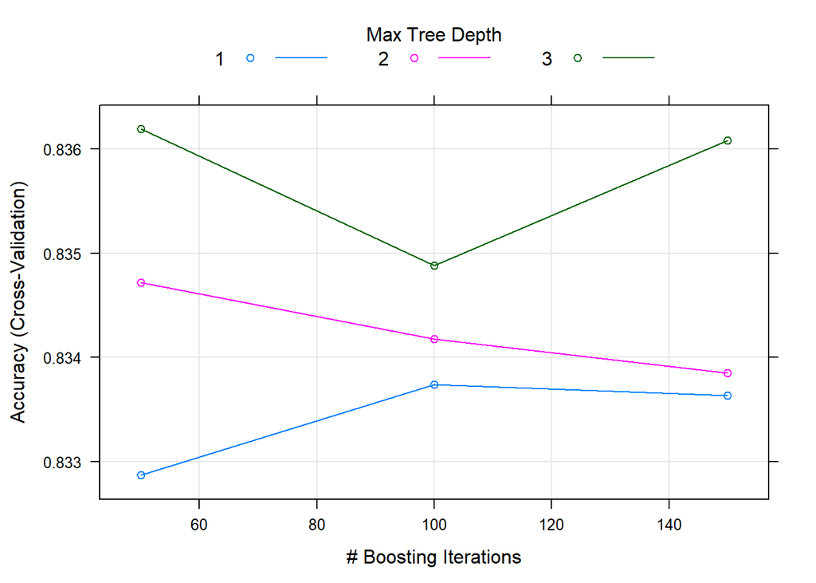

```r
predictionsGBM<-predict(modelgbm,test,type="prob")[,2]
predictionsGBMtrain<-predict(modelgbm,train,type="prob")[,2]
plot(modelgbm)
```

```r
print(modelgbm)
```

```
## Stochastic Gradient Boosting
##
## 18381 samples
##    22 predictor
##     2 classes: '0', '1'
##
## No pre-processing
## Resampling: Cross-Validated (5 fold)
## Summary of sample sizes: 14706, 14704, 14705, 14705, 14704
## Resampling results across tuning parameters:
##
##   interaction.depth  n.trees  Accuracy   Kappa
##   1                   50      0.8328709  0.1778144
##   1                  100      0.8337414  0.1940634
##   1                  150      0.8336326  0.1967619
##   2                   50      0.8347205  0.1999170
##   2                  100      0.8341767  0.1987011
##   2                  150      0.8338504  0.2111095
##   3                   50      0.8361895  0.2093033
##   3                  100      0.8348840  0.2173995
##   3                  150      0.8360809  0.2295391
##
## Tuning parameter 'shrinkage' was held constant at a value of 0.1
##
## Tuning parameter 'n.minobsinnode' was held constant at a value of 10
## Accuracy was used to select the optimal model using the largest value.
## The final values used for the model were n.trees = 50, interaction.depth
##  = 3, shrinkage = 0.1 and n.minobsinnode = 10.
```

```r
library("xgboost")
library("Matrix")
library(dplyr)
train$Recommended.IND<-as.numeric(train$Recommended.IND)-1

data_variables <- as.matrix(train %>% select(-Recommended.IND))
data_label <- train[,"Recommended.IND"]
data_matrix <- xgb.DMatrix(data = data_variables, label = data_label)

numberOfClasses <- length(unique(train$Recommended.IND))
xgb_params <- list(booster = "gbtree","objective" = "binary:logistic",eta=0.1,gamma=5,max_depth=10)
xgbcv <- xgb.cv( params = xgb_params, data = data_matrix, nrounds = 100, nfold = 10, showsd = T, stratified = T, print.every.n = 10, early.stop.round = 20, maximize = F)
```

[output not shown]

```r
nround    <- xgbcv$best_iteration # number of XGBoost rounds
cv.nfold  <- 10

# Fit cv.nfold * cv.nround XGB models and save OOF predictions
bst_model <- xgb.train(params = xgb_params,
                       data = data_matrix,
                       nrounds = nround)

test$Recommended.IND<-as.numeric(test$Recommended.IND)-1


test_matrix<-xgb.DMatrix(data = as.matrix(test %>% select(-Recommended.IND)))
predictionsXGBoost<-predict(bst_model,newdata=test_matrix)

predictionsXGBoosttrain<-predict(bst_model,newdata=data_matrix)
print(table(predictionsXGBoost>0.5,test$Recommended.IND))
```

```
##
##            0    1
##   FALSE  165  104
##   TRUE   728 4108
```

```r
#Stacking model modelGLM,bst_model(XGBOOST) and ctree and using linear model on top
df<-data.frame(train,a=predictionsGLMtrain,b=predictionsGBMtrain,c=predictionsXGBoosttrain,d=predictionsctreetrain)


library(class)

testdf<-data.frame(test,a=predictionsGLM,b=predictionsGBM,c=predictionsXGBoost,d=predictionsctree)


model<-lm(Recommended.IND~.,data=df)


predictions<-predict(model,testdf)
table(predictions>0.5,test$Recommended.IND)
```

```
##
##            0    1
##   FALSE  195  130
##   TRUE   698 4082
```

```r
##Accuracy increased by stacking models
```

### Future work which can increase accuracy-

Using more terms from corpus may increase the accuracy(but space complexity will increase a lot). The cactegorical values can be encoded by mean or frequency which can increase the accuracy as well. Stacking more model and bagging can also help. You can also use N-grams but will take up more space and time to build models.

Here I have achieved an accuracy of ~84% using 22 variables(including 3 Engineered variables) which is pretty good considering the space and time of the CPU used.